# Three sources, one number

Comparing CHD, GDACS and ADAM cyclone exposure estimates — and a proposed basis for standardised cross-agency monitoring · OCHA Centre for Humanitarian Data

2026-07-31

## What we are asking of this group

We hold three independent estimates of how many people a tropical cyclone exposed: **CHD** (our NHC wind-radii figure), **GDACS** (JRC) and **ADAM** (WFP). A monitoring system eventually has to show responders *one* number.

Decision 1 Adopt a **shared convention for missing data** — that a “not computed” value is a gap, never a zero. Without this, every comparison any of us runs is wrong in the same direction.

Decision 2 Accept that for uncertainty purposes there are **two independent methodologies here, not three**, and treat the GDACS family as one input.

Decision 3 Endorse **MAX-of-sources as the operational alert number**, on the condition that it always ships with **provenance** (which source drove it) and **spread** (how far the others sat).

## What we compared

A common grid: every **storm × admin unit × wind threshold**.

- **935 NHC storms**, seasons 2001–2025
- Country (**adm0**) and subnational (**adm1**)
- Thresholds **34 / 50 / 64 kt** — GDACS carries no 50 kt buffer, so GDACS comparisons use 34 and 64 kt only
- Each value is the storm’s **final converged estimate**, so no source is being judged on a forecast against another’s hindsight

This is deliberately like-for-like. Where the sources still disagree, it is a real methodological difference — not an artefact of comparing different moments in a storm’s life.

935

storms on the common grid

57

of them carry a GDACS **per-country** figure we can compare against

36

have a positive figure from **all three** sources at once

Why those numbers collapse so far is the next slide — and it is the first thing we want agreement on.

## Decision 1 — a “not computed” value is not a zero

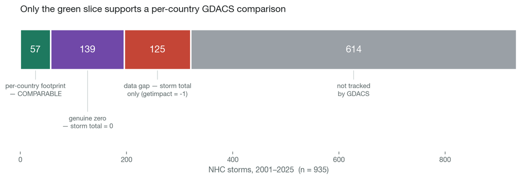

For **125 storms** GDACS reports no per-country figure at all — it returns the code **`-1`, meaning “not computed”**. That is a blank, not a measurement. **Hurricane Maria is one of them**: GDACS sized it at **11.6M people exposed** storm-wide, but never split that figure by country.

Decision 1 Treat a `-1` as **missing**, never as a zero. Score it as “GDACS found nobody” and you invent a disagreement with every source that *did* find people — across 125 storms, including the largest in the record.

The mechanics of how we separate a genuine zero from a blank are in the appendix.

## Decision 2 — ADAM and GDACS are one methodology

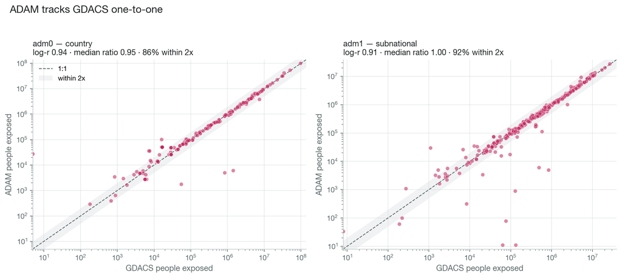

Where both report a positive figure they agree almost perfectly — log-r **0.94** at country level and **0.91** subnationally, median ratio **0.95** and **1.00**, with **86%** and **92%** of estimates within 2×. **90%** of the storms ADAM reports are already in the GDACS positive set.

This is expected, not a criticism: ADAM ingests GDACS upstream. It matters only because two sources agreeing is often read as corroboration — and here it is substantially one methodology reported twice.

## The comparable record is thin, and recent

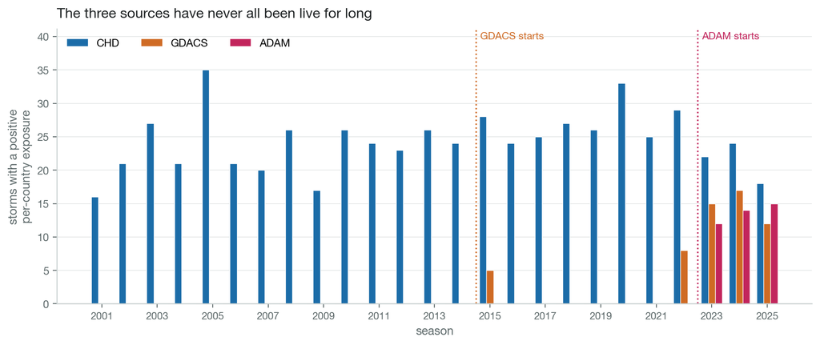

CHD spans the full record (608 storms with a positive per-country figure). GDACS switches on in 2015, ADAM in 2023 — and GDACS’s per-country breakdown is `-1` for most of its early era. All three have only been simultaneously live since **2023: 62 storms**.

So none of what follows is a verdict on any source’s quality over its history. It is what the overlapping window can actually support.

## Missing the breakdown, not the storm

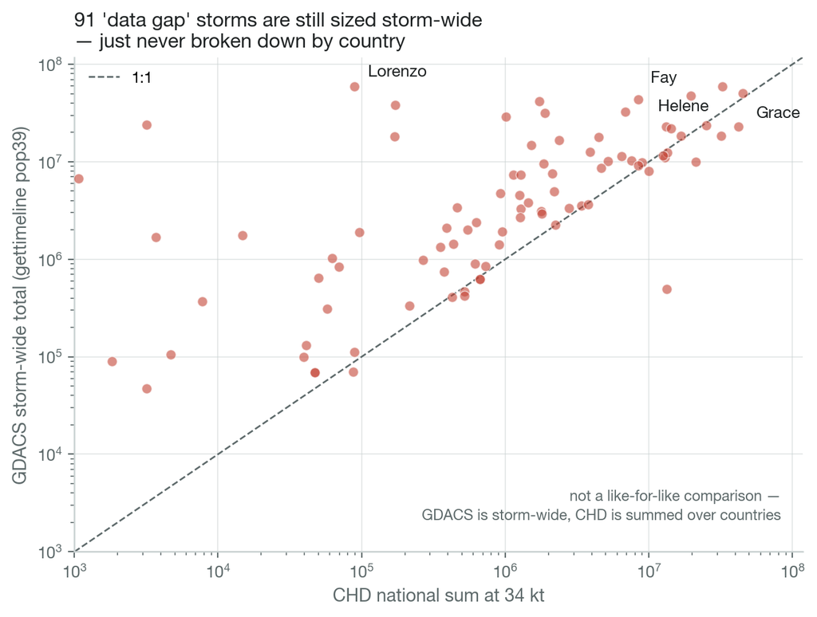

For the **125** “data gap” storms, GDACS has no per-country split but **does** have a storm-wide total — and for **91** of them CHD has a national sum to set beside it.

These storms are recoverable for comparison at the **storm-total grain**, even though they can never enter a per-country grid. That is worth knowing before anyone concludes GDACS “has no data” for 2016–2022.

The two axes are not strictly like-for-like — a storm-wide total versus a sum over countries — so read the position, not the distance from the line.

## Where all three are comparable, CHD reads lower

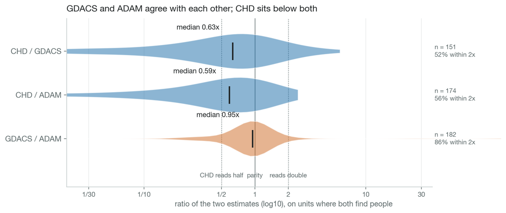

On units where both find people, CHD reports roughly **half** what the GDACS family does — median **0.63×** against GDACS and **0.59×** against ADAM. GDACS against ADAM sits at **0.95×**. The disagreement is systematic and one-directional, not noise.

## …and the gap widens subnationally

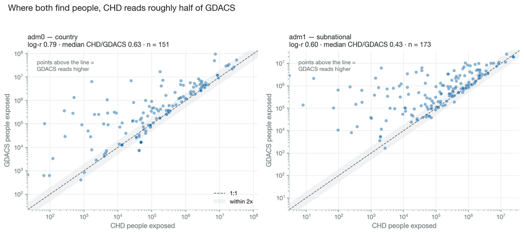

Going from country to subnational, CHD-vs-GDACS correlation falls from log-r **0.79 to 0.60** and the median ratio from **0.63× to 0.43×**. Only about half of paired estimates (**52%** adm0, **46%** adm1) land within 2× of each other.

## Why: same radii, different geometry

**Both start from the same NHC/JTWC advisory wind radii.** The difference is what each does with the four quadrant values.

GDACS

Keeps **only the maximum** of the four quadrant radii and sweeps it as a **symmetric circle**.

“Although the bulletins list wind field information for each of the four cardinal quadrants (describing an asymmetrical wind field), the GDACS system takes **only the maximum of the four values, discarding the rest**, to build a maximalist symmetrical wind field.” — JRC, *GDACS MHEWS guide*

CHD

Interpolates **all four quadrants** into an **asymmetric polygon**.

The physically realistic shape: a cyclone’s 34 kt extent is routinely two to three times larger on one side of the eye than the other.

A max-radius circle **always encloses** the quadrant polygon it was built from. So CHD ≤ GDACS is **structural, not incidental** — and JRC intends it: they take the maximum *“to be conservative on the number of people affected”*, noting the affected area is thereby **overestimated**.

Sources: European Commission JRC, *GDACS Multi-hazard Early Warning System* (JRC141661, 2025; doi 10.2760/1461943) · Vernaccini, De Groeve & Gadenz, *Humanitarian Impact of Tropical Cyclones*, JRC, EUR 23083 EN, 2007, §2.2.

## What that looks like on one storm

[figure not shown]

## The check we expected to lose

We assumed NHC’s own picture would look like the GDACS circle and vindicate the larger number. **It does not.** NHC’s published advisory wind field for Franklin covers **0% of Haiti** — the same as CHD, and it is the shape CHD is reproducing.

Source: NHC GIS archive, `al082023_fcst_*` initial wind radii, all 20 advisories.

**But nobody is verified here.** NHC’s post-storm report finds that reliable stations in the *Dominican Republic* recorded **no sustained tropical-storm-force winds** (peak gust 45 kt at Barahona), and that **no wind or rainfall data are available for Haiti at all**.

NHC did issue tropical-storm **warnings** for Haiti’s south coast — a warning is a statement about risk, not a measurement.

So the honest reading is not “GDACS invented 6M people”. It is that the max-radius rule turns *an absence of data* in two quadrants into *a presence of population* — and on this storm nobody, including NHC, can say who was right.

## What this does *not* settle

**Which number is right.** We have no ground-truth exposure count to score any source against. A source reading lower is not thereby better calibrated, and CHD reading lower is not evidence that CHD is correct.

**Whether “conservative” is wrong.** For an alerting system, deliberately overestimating the footprint is a defensible choice — it is the same instinct behind taking the MAX. It just needs to be a *known* choice rather than an invisible one.

**How ADAM inherits it.** WFP states ADAM draws on JRC data, and our figures show near-identity with GDACS — but we have **not** found public documentation of ADAM’s footprint construction. That step is inference from the correlation, not a cited fact.

For discussion Can WFP confirm whether ADAM reuses the GDACS wind footprint or rebuilds its own? That single answer decides whether the AAC is looking at two independent estimates or three.

## The deeper disagreement is about *who*, not *how many*

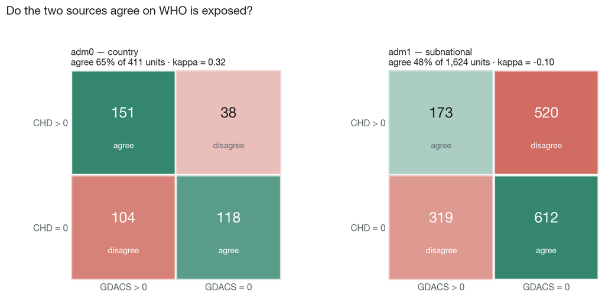

Set magnitude aside and just ask whether a unit is exposed at all. At country level the two sources agree 65% of the time (**κ = 0.32** — modest but real). Subnationally they agree **48%** of the time, **κ = −0.10** — no better than chance.

Cohen’s κ corrects for agreement you would get by chance alone; 0 is chance, 1 is perfect. The subnational cell is where an alert actually points a responder.

## So what do we put on the screen?

The alert pipeline currently takes the **MAX** across available sources: *the highest credible estimate is the operationally relevant one.*

**The case for it**

- No source’s warning is ever suppressed
- Robust to any one source missing a storm
- Trivial to explain and to audit
- Needs no weights, no training, no reference data

**What it costs**

- It is not a consensus figure
- It inherits whichever methodology happens to read highest
- It carries no signal of how much the sources disagreed

Assessed over the all-three-live era only (2023–2025, 62 storms), where a missing value genuinely means “this source found nobody” rather than “this source was not running yet”.

## MAX roughly triples the CHD figure

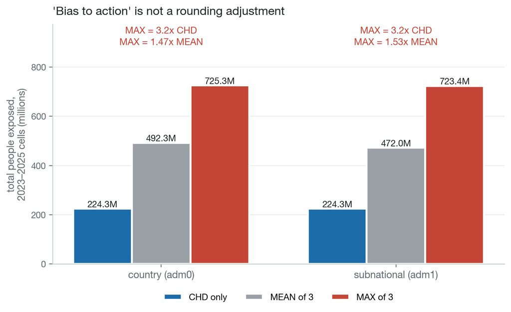

Over the recent era, total exposed is **224M** under CHD alone, **492M** under the mean of three, and **725M** under MAX — **3.2× CHD** and **1.5× the mean**. Bias to action is a real, large shift, not a rounding adjustment.

## Whose number is it? Mostly not ours

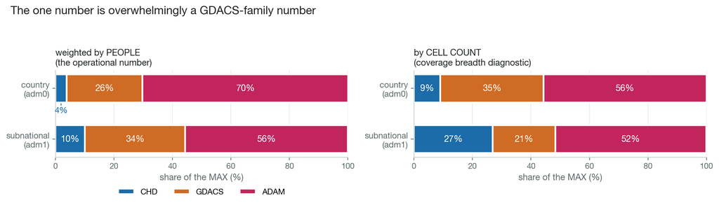

Weighted by the people who actually land in the operational figure, **ADAM supplies 70%** of the country MAX and GDACS most of the rest. **CHD contributes 4%** — and 10% subnationally. The number OCHA shows is overwhelmingly a GDACS-family number.

The right-hand panel counts *cells* instead of people: CHD wins 27% of subnational cells but only 10% of the people, because it reaches many small units that carry few residents. That gap is a coverage-breadth signal, not a second opinion on the headline.

## What the one number hides

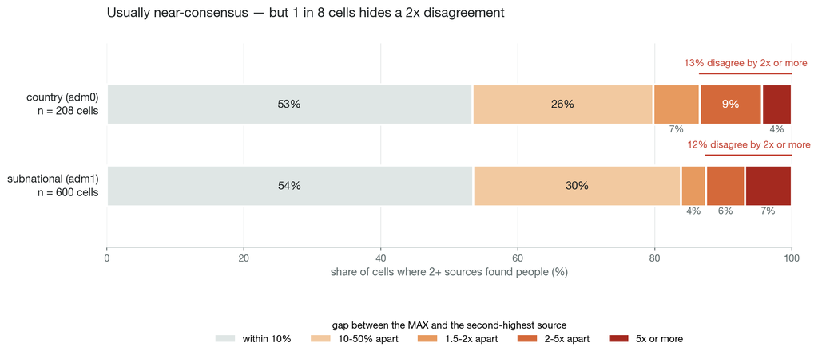

Most of the time MAX is near-consensus — the median cell sits **8%** above the runner-up. But **13%** of country cells and **12%** of subnational cells hide a **2× or larger** disagreement, and 4–7% hide a 5× one. MAX alone gives an operator no way to tell those cases apart.

## One storm’s map is a patchwork of all three

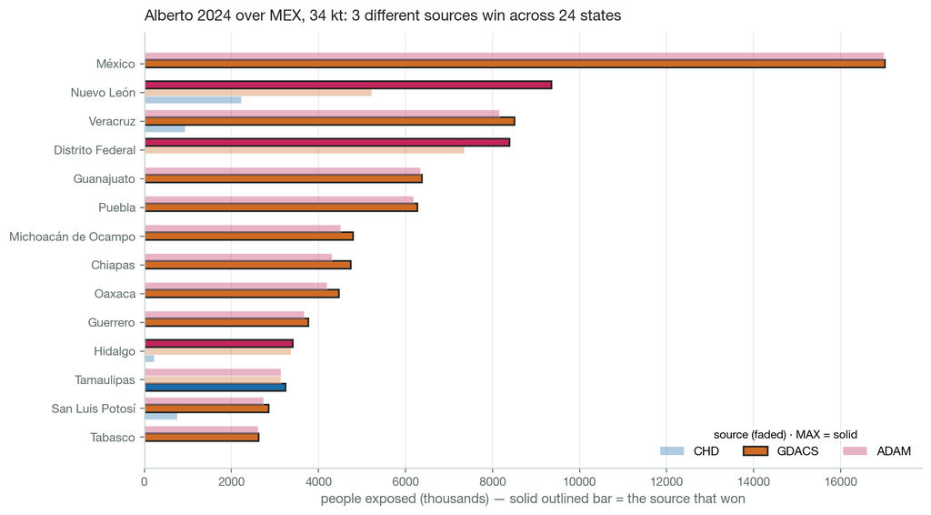

Alberto 2024 over Mexico: across 24 states, **all three sources win somewhere**. The subnational surface a responder reads is a patchwork — Nuevo León is an ADAM number, Veracruz a GDACS one, Tamaulipas a CHD one.

This is inherent to taking a per-unit maximum. It is not wrong, but it means “the exposure map” is not the output of any single methodology.

## The two screens do reconcile

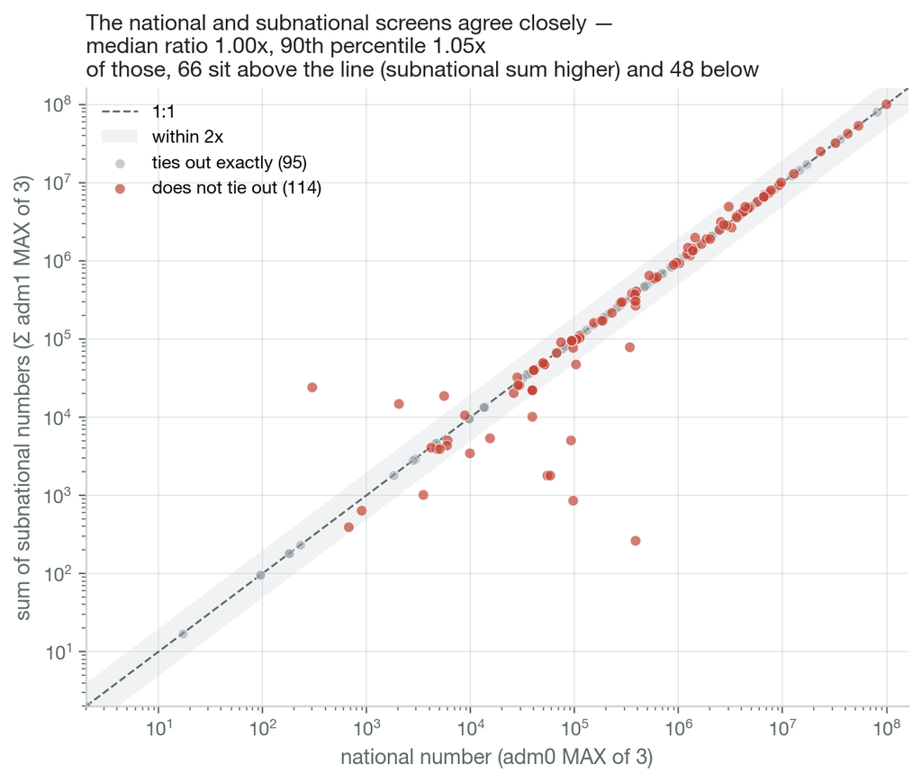

Summing the subnational numbers and comparing to the national one: the median ratio is **1.00×** and the 90th percentile **1.05×**. Each source now reconciles across admin levels, so the residual is per-unit source-switching — modest, with a few real exceptions (Alberto/MEX **+2.2M**, Milton/USA **+2.1M**).

## What we propose

Decision 1 **A shared missing-data convention.** A “not computed” value is a gap, not a zero, in any cross-source comparison any of us publishes.

Decision 2 **Two methodologies, not three.** Treat the GDACS family as a single input when reasoning about agreement or uncertainty — three sources agreeing is really two.

Decision 3 **MAX as the action number, never bare.** Keep MAX for alerting, but publish it with the contributing values, the **provenance** of the winner, and the **spread** — so the 1-in-8 cells with a 2× disagreement are visible rather than buried.

None of this asks any agency to change how it computes exposure. It asks us to agree on how we compare, combine and caveat what we already produce.

## What would help most, from each of us

**JRC / GDACS** — a per-country breakdown wherever a storm total exists (the `-1` era is the single biggest constraint on comparability), and adm0/adm1 figures that reconcile with each other.

**WFP / ADAM** — explicit flagging of where a figure is re-derived from GDACS versus computed independently, so downstream users can tell corroboration from duplication.

**OCHA / CHD** — we publish the harmonised grid, the five-case fills and this comparison in full, and will carry provenance and spread through to the alert product.

The prize is a monitoring product where a number’s **origin and uncertainty travel with it** — which is what makes it usable by agencies that did not compute it.

## Where this is weakest

- **The per-country comparison rests on 57 storms**, and the all-three-live era on 62 storms. Rankings and directions are robust; precise magnitudes are not.
- **The three pairwise comparisons run on different, largely non-overlapping storm sets**, so their correlations are not directly comparable with each other.
- **No ground truth.** We can measure that the sources disagree and characterise how — we cannot say which is closer to the true exposed population.
- **Operational windows differ** (GDACS 2015+, ADAM 2023+); everything here is read on a same-era footing, which is why the 2023–2025 window carries the MAX analysis.

Treat this as a carefully worked characterisation of *how these sources relate*, and a method any of us can re-run — not a verdict on any source’s quality.

## Next steps

1. **Agreement in principle** on the three decisions — today, or by written procedure if the cell prefers.
2. **Confirmation from WFP** on how ADAM builds its wind footprint — the one open question behind Decision 2.
3. **Provenance and spread into the alert product** — we can carry these through without any change upstream.
4. **Re-run on the 2026 season** once it closes, to test whether the patterns here hold as the all-three-live record grows.

Full methodology, code and the underlying chapters: `OCHA-DAP/ds-storm-impact-harmonisation` — chapters 09 (source comparison) and 10 (MAX methodology).

# Appendix

Detail behind Decision 1 — how a genuine zero is told apart from a blank

## The problem, in plain terms

Ask GDACS *“how many people did this storm expose in Honduras?”* and for many storms the answer that comes back is **`-1`**.

**`-1` is not a population.** It is a status code meaning *we did not compute this*. GDACS is being honest — it is telling you it has no answer, not that the answer is nobody.

The trap is what happens next. Anyone tidying that data has to do *something* with the `-1`, and the tempting move is to treat it as **0**. At that point the record silently changes meaning: *“GDACS did not answer”* becomes *“GDACS said nobody was exposed.”*

**Why it wrecks a comparison.** CHD *does* have a figure for those storm-countries. So every `-1` converted to a 0 manufactures a fake disagreement — CHD says millions, GDACS apparently says none.

Across **125 storms** that would produce an enormous, entirely artificial gap between the two sources, and any conclusion drawn from it would be wrong.

## Why the two endpoints matter

GDACS answers the exposure question in **two different places**, and the difference is what makes the problem solvable:

**`getimpact` — per country**

The only source of a country-by-country breakdown. This is the one that returns `-1` for GDACS’s ~2016–2022 era.

**`gettimeline` — one storm-wide total**

A single number for the whole wind footprint, summed across every area. Available throughout, including where `getimpact` is `-1`.

**The storm-wide total is the discriminator.** If it is **0**, the storm exposed nobody anywhere — so a blank per country is a genuine zero. If it is **large**, people clearly were exposed — so a blank per country is a gap in the breakdown, not an absence of people.

Maria: `getimpact` = `-1` for every country, `gettimeline` = 11.6M people. The second number is what tells you the first one is a blank rather than a zero.

## The five-case rule

Each (storm, country, threshold) GDACS cell is filled **0** or **missing** by five cases — this is the rule Decision 1 asks the cell to adopt:

|  | situation | fill |
| --- | --- | --- |
| 1 | positive per-country value | the value |
| 2 | GDACS computed that threshold, this country **absent** from the footprint | **0** |
| 3 | **storm total = 0** — it exposed nobody | **0** |
| 4 | per-country `-1`, **or** no per-country value but **storm total > 0** | **missing** |
| 5 | storm not tracked, or 50 kt (no GDACS buffer) | **missing** |

Cases 2 and 3 are the *defensible* zeros — GDACS genuinely placed nobody there. Cases 4 and 5 are blanks and are held out of the comparison entirely rather than counted against any source.

CHD is our own database, so a missing value there is a true 0. GDACS carries no 50 kt buffer, which is why GDACS comparisons run at 34 and 64 kt only.

[interactive chart not shown]